# Introduction to Python

## 存檔、讀取圖檔

```
plt.savefig(fname, dpi=None, facecolor='w', edgecolor='w',
        orientation='portrait', papertype=None, format=None,
        transparent=False, bbox_inches=None, pad_inches=0.1,
        frameon=None)
```

`plt.imread()` Return value is a numpy.array. For grayscale images, the return array is MxN.

For RGB images, the return value is MxNx3. For RGBA images the return value is MxNx4.

`plt.imshow()`  
array_like, shape (n, m) or (n, m, 3) or (n, m, 4)

Display the image in X to current axes. X may be an array or a PIL image. If X is an array, it can have the following shapes and types:

MxN – values to be mapped (float or int) MxNx3 – RGB (float or uint8) MxNx4 – RGBA (float or uint8)

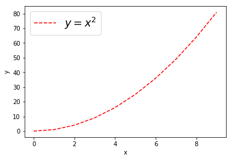

```python
%matplotlib inline

import numpy as np
import matplotlib.pyplot as plt

x = np.arange(10)
y = x**2

plt.plot(x, y, 'r--',label= r'$y=x^2$')
plt.xlabel('x')
plt.ylabel('y')

plt.legend(loc='best', fontsize=18)

plt.savefig('fig.png', format='png')
# 格式可為 png、pdf、ps、eps、svg
```

```python
%matplotlib inline

import numpy as np
import matplotlib.pyplot as plt

readfig = plt.imread('fig.png')

print(readfig.shape, readfig.dtype)
# x:由左而右   y:由上而下

#imshow 所畫圖之正y軸的方向是由上而下，若設定origin參數為lower則所顯示得圖之原點在左下角，可使圖顛倒

#若元素數值為浮點數，則數值為0.0~1.0 對應顏色值為0~255，超過此範圍會出現異常顯示

#plt.imshow(readfig)

#plt.imshow(readfig, cmap='rainbow', origin='lower')
#plt.imshow(readfig-0.1)
#plt.imshow(readfig/255.0)
#plt.imshow(readfig[:, 150:200,:])
```

```
(288, 432, 4) float32
```

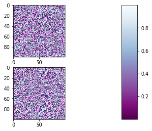

```python
%matplotlib inline

import matplotlib.pyplot as plt
import numpy as np

plt.subplot(211)
plt.imshow(np.random.random((100, 100)), cmap=plt.cm.BuPu_r)
plt.subplot(212)
plt.imshow(np.random.random((100, 100)), cmap=plt.cm.BuPu_r)

plt.subplots_adjust(bottom=0.1, right=0.8, top=0.9)

cax = plt.axes([0.85, 0.1, 0.075, 0.8])
plt.colorbar(cax=cax)
# cax: Axis into which the colorbar will be drawn
# shrink: 1.0; fraction by which to multiply the size of the colorbar
```

# Example : random walk problem in 2D

```
Text(0,0.5,'$\\sqrt{\\langle (\\delta x)^2 \\rangle}$')
```

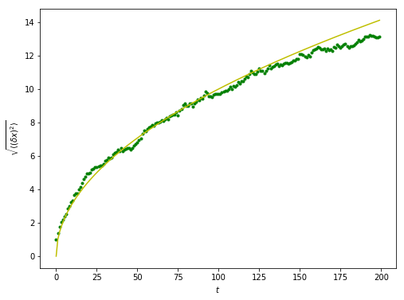

```python
%matplotlib inline

import numpy as np
import matplotlib.pyplot as plt

# create 1000 realizations with 200 steps each
n_times = 100
t_max = 200
t = np.arange(t_max)

# Steps can be -1 or 1 (note that randint excludes the upper limit)
steps = 2 * np.random.randint(0, 1 + 1, (n_times, t_max)) - 1  # shape= (n_times, t_max)

# print(steps)

# The time evolution of the position is obtained by successively
# summing up individual steps. This is done for each of the
# realizations, i.e. along axis 1.
positions = np.cumsum(steps, axis=1) #Return the cumulative sum of the elements along a given axis.


# Determine the time evolution of the mean square distance.
sq_distance = positions**2
mean_sq_distance = np.mean(sq_distance, axis=0)


# Plot the distance d from the origin as a function of time and
# compare with the theoretically expected result where d(t)
# grows as a square root of time t.
plt.figure(figsize=(8, 6))
plt.plot(t, np.sqrt(mean_sq_distance), 'g.', t, np.sqrt(t), 'y-')
plt.xlabel(r"$t$")
plt.ylabel(r"$\sqrt{\langle (\delta x)^2 \rangle}$")
#plt.tight_layout()
#plt.show()
```

# meshgrid

- 將原生數值變成格點
- 讓`等高線圖(contour)`、`向量箭頭圖(quiver)`、`流線圖(streamplot)`、`3D 圖(mplot3d)` 可吃的格式

```python
import numpy as np

x = np.array([1,2,3,4])
y = np.array([5,6,7,8])

X, Y = np.meshgrid(x,y)

print(X)
print(Y)
```

```
[[1 2 3 4]
 [1 2 3 4]
 [1 2 3 4]
 [1 2 3 4]]
[[5 5 5 5]
 [6 6 6 6]
 [7 7 7 7]
 [8 8 8 8]]
```

說明

[figure not shown]

# contour plot

`plt.contour()`

`plt.contouf()`

```
<a list of 23 text.Text objects>
```

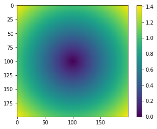

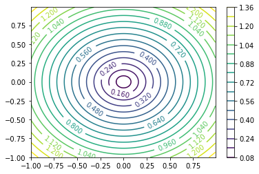

```python
%matplotlib inline

import numpy as np
import matplotlib.pyplot as plt

x, y = np.meshgrid(np.arange(-1, 1, 0.01), np.arange(-1, 1, 0.01))

z = np.sqrt(x ** 2 + y ** 2)
plt.imshow(z)
plt.colorbar()

plt.figure()


CS = plt.contour(x, y, z, 20)  #20為等高線數量
plt.colorbar()
plt.clabel(CS)  # 標示等高線數值
```

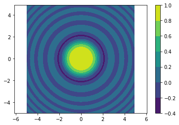

```python
%matplotlib inline

import numpy as np
import matplotlib.pyplot as plt

x = np.arange(-5, 5, 0.1)
y = np.arange(-5, 5, 0.1)

xx, yy = np.meshgrid(x, y, sparse=True)
z = np.sin(xx**2 + yy**2) / (xx**2 + yy**2)

h = plt.contourf(x,y,z)
plt.axis('equal')
plt.colorbar()
```

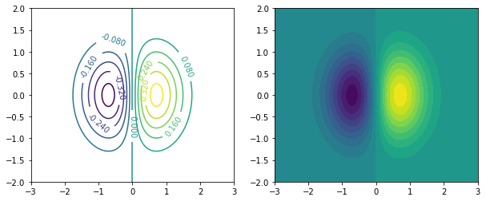

```python
%matplotlib inline

import numpy as np
import matplotlib.pyplot as plt

y,  x =  np.ogrid[-2:2:200j,  -3:3:300j]
z  = x * np.exp(-x**2 - y**2)

extent = [np.min(x), np.max(x), np.min(y), np.max(y)]

plt.figure(figsize=(10,4))
plt.subplot(121)

cs = plt.contour(z,  10,  extent=extent)
plt.clabel(cs)

plt.subplot(122)
plt.contourf(x.reshape(-1),  y.reshape(-1),  z,  20)
```

## 箭頭向量圖

Plot a 2-D field of arrows.

`plt.quiver(X, Y, U, V, C)`

U and V are the arrow data, X and Y set the location of the arrows, and C sets the color of the arrows. These arguments may be 1-D or 2-D arrays or sequences.

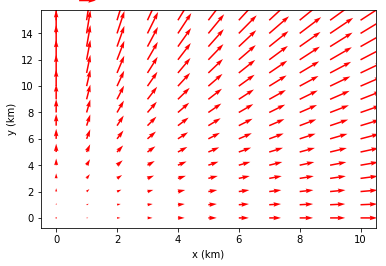

```python
%matplotlib inline

import numpy as np
import matplotlib.pyplot as plt


#from mpl_toolkits.mplot3d import Axes3D

x = np.linspace(0,10,11)
y = np.linspace(0,15,16)

(X,Y) = np.meshgrid(x,y)

u = 5*X
v = 5*Y

q = plt.quiver(X,Y,u,v,angles='xy',scale=1000,color='r')
p = plt.quiverkey(q,1,16.5,50,"50 m/s",coordinates='data',color='r')

xl = plt.xlabel("x (km)")
yl = plt.ylabel("y (km)")
```

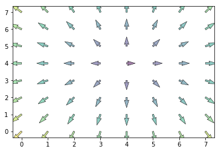

```python
%matplotlib inline

import numpy as np
import matplotlib.pyplot as plt

n = 8

X, Y = np.meshgrid(np.arange(n), np.arange(n))
#X, Y = np.mgrid[0:n, 0:n]

T = np.arctan2(Y - n/ 2., X - n / 2.)

R = 10 + np.sqrt((Y - n / 2.) ** 2 + (X - n / 2.) ** 2)

U, V = R * np.cos(T), R * np.sin(T)

plt.quiver(X, Y, U, V, R, alpha=.5)
plt.quiver(X, Y, U, V, edgecolor='k', facecolor='None', linewidth=.5)
```

## streamplot

display 2D vector fields

`plt.streamplot(x, y, u, v, density=1)`

x, y : 1d arrays， an evenly spaced grid.

u, v : 2d arrays， x and y-velocities. Number of rows should match length of y, and the number of columns should match x.

density : float or 2-tuple

Controls the closeness of streamlines. When density = 1, the domain is divided into a 30x30 grid—density linearly scales this grid. Each cell in the grid can have, at most, one traversing streamline. For different densities in each direction, use [density_x, density_y].

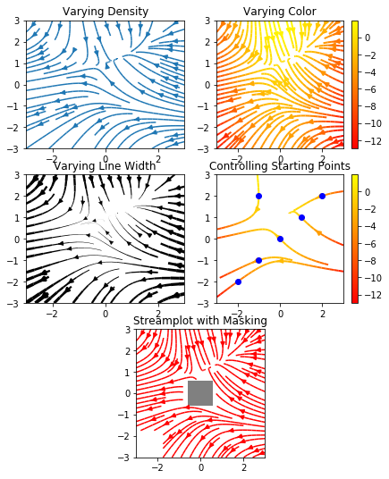

```python
%matplotlib inline

import numpy as np
import matplotlib.pyplot as plt


w = 3
Y, X = np.mgrid[-w:w:100j, -w:w:100j]
U = -1 - X**2 + Y
V = 1 + X - Y**2
speed = np.sqrt(U*U + V*V)

fig = plt.figure(figsize=(7, 9))


#  Varying density along a streamline
ax0 = fig.add_subplot(3, 2, 1)
ax0.streamplot(X, Y, U, V, density=[0.5, 1])
ax0.set_title('Varying Density')


# Varying color along a streamline
ax1 = fig.add_subplot(3, 2, 2)
strm = ax1.streamplot(X, Y, U, V, color=U, linewidth=2, cmap='autumn')
fig.colorbar(strm.lines)
ax1.set_title('Varying Color')


#  Varying line width along a streamline
ax2 = fig.add_subplot(3, 2, 3)
lw = 5*speed / speed.max()
ax2.streamplot(X, Y, U, V, density=0.6, color='k', linewidth=lw)
ax2.set_title('Varying Line Width')


# Controlling the starting points of the streamlines
seed_points = np.array([[-2, -1, 0, 1, 2, -1], [-2, -1,  0, 1, 2, 2]])

ax3 = fig.add_subplot(3, 2, 4)
strm = ax3.streamplot(X, Y, U, V, color=U, linewidth=2,
                     cmap='autumn', start_points=seed_points.T)
fig.colorbar(strm.lines)
ax3.set_title('Controlling Starting Points')

# Displaying the starting points with blue symbols.
ax3.plot(seed_points[0], seed_points[1], 'bo')
ax3.axis((-w, w, -w, w))

# Create a mask
mask = np.zeros(U.shape, dtype=bool)
mask[40:60, 40:60] = True
U[:20, :20] = np.nan
U = np.ma.array(U, mask=mask)

ax4 = fig.add_subplot(3, 1, 3)
ax4.streamplot(X, Y, U, V, color='r')
ax4.set_title('Streamplot with Masking')

ax4.imshow(~mask, extent=(-w, w, -w, w), alpha=0.5,
          interpolation='nearest', cmap='gray', aspect='auto')
ax4.set_aspect('equal')
```

## 3D 繪圖

mplot3d:

`from mpl_toolkits.mplot3d import Axes3D`

`fig = plt.figure()`

`ax = Axes3D(fig)`

或者

`ax = fig.gca(projection='3d')`

或者

`ax = plt.axes(projection='3d')`

- https://matplotlib.org/examples/mplot3d/index.html
- https://matplotlib.org/mpl_toolkits/mplot3d/tutorial.html
- https://matplotlib.org/mpl_toolkits/mplot3d/index.html

```
(-2, 2)
```

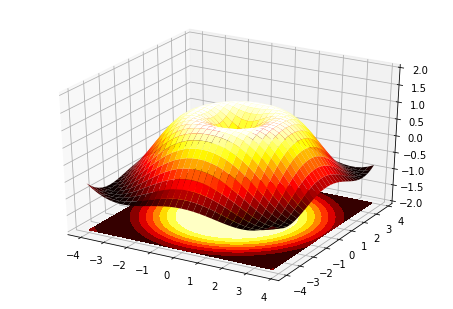

```python
%matplotlib inline

import numpy as np
import matplotlib.pyplot as plt
from mpl_toolkits.mplot3d import Axes3D

fig = plt.figure()
ax = Axes3D(fig)

X = np.arange(-4, 4, 0.25)
Y = np.arange(-4, 4, 0.25)
X, Y = np.meshgrid(X, Y)

R = np.sqrt(X ** 2 + Y ** 2)
Z = np.sin(R)

ax.plot_surface(X, Y, Z, rstride=1, cstride=1, cmap=plt.cm.hot)
# rstride: Array row stride (step size)
# cstride: Array column stride (step size)
# rcount: Use at most this many rows, defaults to 50
# ccount: Use at most this many columns, defaults to 50


ax.contourf(X, Y, Z, zdir='z', offset=-2, cmap=plt.cm.hot) # z投影，壓到z=-2
ax.set_zlim(-2, 2)
```

```
[<mpl_toolkits.mplot3d.art3d.Line3D at 0x250f45fa860>]
```

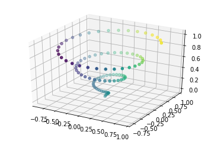

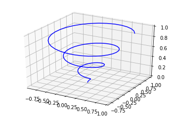

```python
%matplotlib inline

#3D scatter plot
import numpy as np
import matplotlib.pyplot as plt
from mpl_toolkits.mplot3d import Axes3D

fig = plt.figure()
ax = plt.axes(projection='3d')

z = np.linspace(0, 1, 100)
x = z * np.sin(20 * z)
y = z * np.cos(20 * z)
c = x + y

ax.scatter(x, y, z, c=c)


#3D line plot
fig = plt.figure()
ax = plt.axes(projection='3d')

ax.plot(x, y, z, '-b')
```

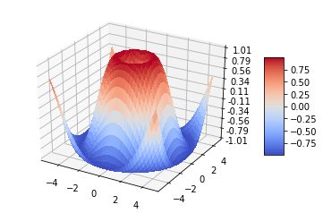

```python
%matplotlib inline

from mpl_toolkits.mplot3d import Axes3D
import matplotlib.pyplot as plt
from matplotlib import cm
from matplotlib.ticker import LinearLocator, FormatStrFormatter
import numpy as np


fig = plt.figure()
ax = fig.gca(projection='3d')

# Make data.
X = np.arange(-5, 5, 0.25)
Y = np.arange(-5, 5, 0.25)
X, Y = np.meshgrid(X, Y)
R = np.sqrt(X**2 + Y**2)
Z = np.sin(R)

# Plot the surface.
surf = ax.plot_surface(X, Y, Z, cmap=cm.coolwarm,
                       linewidth=0, antialiased=False)

# Customize the z axis.
ax.set_zlim(-1.01, 1.01)
ax.zaxis.set_major_locator(LinearLocator(10))
ax.zaxis.set_major_formatter(FormatStrFormatter('%.02f'))

# Add a color bar which maps values to colors.
fig.colorbar(surf, shrink=0.5, aspect=5)
```

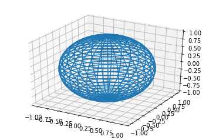

```python
%matplotlib inline
import numpy as np
import matplotlib.pyplot as plt
from mpl_toolkits.mplot3d import Axes3D

#3D wire-frame
u = np.linspace(0, np.pi, 30)
v = np.linspace(0, 2 * np.pi, 30)

x = np.outer(np.sin(u), np.sin(v))  # 外積
y = np.outer(np.sin(u), np.cos(v))
z = np.outer(np.cos(u), np.ones_like(v))


fig = plt.figure()
ax = plt.axes(projection='3d')

ax.plot_wireframe(x, y, z)
```

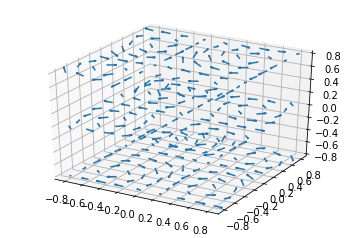

```python
%matplotlib inline
import numpy as np
import matplotlib.pyplot as plt
from mpl_toolkits.mplot3d import axes3d


fig = plt.figure()
ax = fig.gca(projection='3d')

# Make the grid
x, y, z = np.meshgrid(np.arange(-0.8, 1, 0.2),
                      np.arange(-0.8, 1, 0.2),
                      np.arange(-0.8, 1, 0.8))

# Make the direction data for the arrows
u = np.sin(np.pi * x) * np.cos(np.pi * y) * np.cos(np.pi * z)
v = -np.cos(np.pi * x) * np.sin(np.pi * y) * np.cos(np.pi * z)
w = (np.sqrt(2.0 / 3.0) * np.cos(np.pi * x) * np.cos(np.pi * y) *
     np.sin(np.pi * z))

ax.quiver(x, y, z, u, v, w, length=0.1, normalize=True)
```

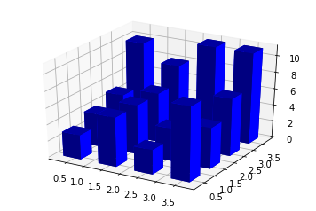

```python
%matplotlib inline
import numpy as np
import matplotlib.pyplot as plt
from mpl_toolkits.mplot3d import Axes3D

# 3D histogram
fig = plt.figure()
ax = fig.add_subplot(111, projection='3d')
x, y = np.random.rand(2, 100) * 4
hist, xedges, yedges = np.histogram2d(x, y, bins=4, range=[[0, 4], [0, 4]])

# Construct arrays for the anchor positions of the 16 bars.
# Note: np.meshgrid gives arrays in (ny, nx) so we use 'F' to flatten xpos,
# ypos in column-major order. For numpy >= 1.7, we could instead call meshgrid
# with indexing='ij'.
xpos, ypos = np.meshgrid(xedges[:-1] + 0.25, yedges[:-1] + 0.25)
xpos = xpos.flatten('F')
ypos = ypos.flatten('F')
zpos = np.zeros_like(xpos)

# Construct arrays with the dimensions for the 16 bars.
dx = 0.5 * np.ones_like(zpos)
dy = dx.copy()
dz = hist.flatten()

ax.bar3d(xpos, ypos, zpos, dx, dy, dz, color='b', zsort='average')
```

# animation 動畫

需利用文字編輯器另外執行

`import matplotlib.animation as animation`

```
animation.FuncAnimation(fig, animate, np.arange(1, len(y)),
                              interval=25, blit=True, init_func=init)
```

- https://matplotlib.org/api/_as_gen/matplotlib.animation.FuncAnimation.html
- https://matplotlib.org/examples/animation/index.html

```python
# animation line plot
import numpy as np
import matplotlib.pyplot as plt
import matplotlib.animation as animation

fig, ax = plt.subplots()

x = np.arange(0, 2*np.pi, 0.01)
line, = ax.plot(x, np.sin(x))


def animate(i):
    line.set_ydata(np.sin(x + i / 50))  # update the data.
    return line,


ani = animation.FuncAnimation(
    fig, animate, interval=20, blit=True, save_count=50)

# To save the animation, use e.g.
#
# ani.save("movie.mp4")
#
# or
#
# writer = animation.FFMpegWriter(
#     fps=15, metadata=dict(artist='Me'), bitrate=1800)
# ani.save("movie.mp4", writer=writer)

plt.show()
```

[figure not shown]

```python
# animation SIN line plot 2

from matplotlib import pyplot as plt
from matplotlib import animation
import numpy as np

fig, ax = plt.subplots()

x = np.arange(0, 2*np.pi, 0.01)
line, = ax.plot(x, np.sin(x))
ax.set_aspect(1.0) # 使圖片長寬變成1:1

# 定義動畫函數，用來更新每個frame上 x 對應的 y 值，參數 i 表示第 i 個frame
def animate(i):
    line.set_ydata(np.sin(x + i/10.0))
    return line,

# 定義起始函數
def init():
    line.set_ydata(np.sin(x))
    return line,

#fig：畫動畫的figure
#func: 動畫函數，給animate
#frames: 動畫長度，一次循環的frame數
#init_func： 起始frame，給init
#interval: 更新頻率，以 ms為單位，預設為200 ms(Delay between frames in milliseconds)
#blit: 更新所有數據點或只更新改變的數據點
ani = animation.FuncAnimation(fig=fig,
                              func=animate,
                              frames=100,
                              init_func=init,
                              interval=20,
                              blit=False)

plt.show()
```

```python
# animation SIN line plot 3

"""
Matplotlib Animation Example

author: Jake Vanderplas
email: vanderplas@astro.washington.edu
website: http://jakevdp.github.com
license: BSD
Please feel free to use and modify this, but keep the above information. Thanks!
"""

import numpy as np
from matplotlib import pyplot as plt
from matplotlib import animation

# First set up the figure, the axis, and the plot element we want to animate
fig = plt.figure()
ax = plt.axes(xlim=(0, 2), ylim=(-2, 2))
line, = ax.plot([], [], lw=2)

# initialization function: plot the background of each frame
def init():
    line.set_data([], [])
    return line,

# animation function.  This is called sequentially
def animate(i):
    x = np.linspace(0, 2, 1000)
    y = np.sin(2 * np.pi * (x - 0.01 * i))
    line.set_data(x, y)
    return line,

# call the animator.  blit=True means only re-draw the parts that have changed.
anim = animation.FuncAnimation(fig, animate, init_func=init,
                               frames=200, interval=20, blit=True)

# save the animation as an mp4.  This requires ffmpeg or mencoder to be
# installed.  The extra_args ensure that the x264 codec is used, so that
# the video can be embedded in html5.  You may need to adjust this for
# your system: for more information, see
# http://matplotlib.sourceforge.net/api/animation_api.html

#anim.save('basic_animation.mp4', fps=30, extra_args=['-vcodec', 'libx264'])

plt.show()
```

```python
# animation SIN dot plot

import numpy as np
import matplotlib.pyplot as plt
from matplotlib.animation import FuncAnimation

fig, ax = plt.subplots()
xdata, ydata = [], []
ln, = plt.plot([], [], 'ro', animated=True)

def init():
    ax.set_xlim(0, 2*np.pi)
    ax.set_ylim(-1, 1)
    return ln,

def update(frame):
    xdata.append(frame)
    ydata.append(np.sin(frame))
    ln.set_data(xdata, ydata)
    return ln,

ani = FuncAnimation(fig, update, frames=np.linspace(0, 2*np.pi, 128),
                    init_func=init, blit=True)
plt.show()
```

```python
#from 王一哲  http://keejko.blogspot.com/2019/12/matplotlib_20.html

import numpy as np
import matplotlib.pyplot as plt
import matplotlib.animation as animation

"""
 1.參數設定
"""
xmin, xmax, A, N = 0, 4*np.pi, 4, 100
x = np.linspace(xmin, xmax, N)
y = A*np.sin(x)

'''
參數設定
繪圖範圍最小值 xmin = 0
繪圖範圍最大值 xmax = 4π
振幅 A = 4
動畫格數 N = 100
利用 numpy.linspace 產生 0 到 4π，分為 100 等份的一維陣列 x。
將 x 代入 A* sin(x) 計算對應的值並存入一維陣列 y。

'''


"""
 2.繪圖
"""
fig = plt.figure(figsize=(7, 6), dpi=100)
ax = fig.gca()
line, = ax.plot(x, y, color='blue', linestyle='-', linewidth=3)
dot, = ax.plot([], [], color='red', marker='o', markersize=10, markeredgecolor='black', linestyle='')
ax.set_xlabel('x', fontsize=14)
ax.set_ylabel('y', fontsize=14)

def update(i):
    dot.set_data(x[i], y[i])
    return dot,

def init():
    dot.set_data(x[0], y[0])
    return dot,

ani = animation.FuncAnimation(fig=fig, func=update, frames=N, init_func=init, interval=1000/N, blit=True, repeat=True)
plt.show()
ani.save('MovingPointMatplotlib.gif', writer='imagemagick', fps=1/0.04)


'''
繪圖
以陣列x、y的資料繪圖，格式為藍色實線，線寬為3：
line, = ax.plot(x, y, 'b-', lw=3)
設定移動點的格式為紅色實心的點，點的寬度為10，點的邊綠為黑色實線：
dot, = ax.plot([], [], 'ro', ms=10, mec='k')
自訂函式update，使用set_data更新點的位置。
自訂函式init，使用set_data畫點的起始位置。由於我們要畫的點起始位置儲存在陣列x、y當中索引值為0的位置，其實可以刪除這個自訂函式

ani = animation.FuncAnimation(fig, update, N, interval=1000/N, blit=True)
matplotlib.animation.FuncAnimation 繪製動畫，選項為
fig：目標圖片
func：更新圖片使用的函式
frames：圖片總數
init_func：起始圖片
interval：更新圖片時間間隔
blit：若只更新圖片上會改變的部分設定為True，反之則設定為False。經過測試後發現，若設定為True，則使用plt.show()顯示圖片時會比較順，但是不會影響到產生的gif檔大小。
repeat：是否重複執行動畫，預設值為True。

顯示圖片，如果只要產生gif檔，可以省略此行。
使用imagemagick將圖片存成gif檔，檔名為MovingPointMatplotlib.gif，fps為每秒更新的圖片數量。
需安裝 imagemagick
'''
```

```python
#Standing Wave 2d

import numpy as np
from numpy import pi
import matplotlib.pyplot as plt
import matplotlib.animation as animation

plt.style.use('dark_background')

fig = plt.figure()
fig.set_dpi(100)
ax1 = fig.add_subplot(1,1,1)

#Wave speed
c = 1

#x axis
x0 = np.linspace(-pi,pi,10000)

#Initial time
t0 = 0

#Time increment
dt = 0.05

#Wave equation solution
def u(x,t):
    return 0.5*(np.sin(x+c*t) + np.sin(x-c*t))

a = []

for i in range(500):
    value = u(x0,t0)
    t0 = t0 + dt
    a.append(value)

k = 0
def animate(i):
    global k
    x = a[k]
    k += 1
    ax1.clear()
    plt.plot(x0,x,color='cyan')
    plt.grid(True)
    plt.ylim([-2,2])
    plt.xlim([-pi,pi])

anim = animation.FuncAnimation(fig,animate,frames=360,interval=20)
plt.show()
```

```python
# wave 3d

#encoding: utf-8
# not yet finished

import numpy as np
import scipy as sp
import matplotlib.pyplot as plt
import matplotlib.animation as animation
from mpl_toolkits.mplot3d import Axes3D
import matplotlib.mlab as mlab
#from matplotlib.mlab import griddata


#A test for surface plot and wireframe plot
'''
lep = 0.0 # Left end-point for x
rep = 5.0 # Right end-point for x
NP = 100 # Number of points (number of intervals = np-1)

x = np.linspace(lep, rep, NP)
y = np.linspace(lep, rep, NP)
xv, yv = np.meshgrid(x, y)
zv = np.sin(xv) * np.cos(yv*xv)

fig = plt.figure()
ax = fig.add_subplot(111, projection='3d')
#ax2 = fig.add_subplot(121,projection='3d')
#ax2.plot_wireframe(xv,yv,zv)
sur = ax.plot_surface(xv,yv,zv,
                #rstride=1,  #Array row stride (step size)
                #cstride=1,
                #rcount=100,ccount=100  #Use at most this many rows, defaults to 50
                cmap="jet"
                )
plt.colorbar(sur, orientation='vertical')

plt.show()
'''

#2D traveling wave

def data(i,z,line):
    z = np.sin(x+y+i)
    ax.clear()
    line = ax.plot_surface(x,y,z, color='b')
    return line,

m = 2 * np.pi
fig = plt.figure()
ax = fig.add_subplot(111, projection='3d')

x = np.linspace(0, m, 100)
y = np.linspace(0, m, 100)
x, y = np.meshgrid(x, y)
z = np.sin(x+y)
line = ax.plot_surface(x, y, z, color='b')

ani = animation.FuncAnimation(fig, data, fargs=(z, line), interval=1, blit=False)

plt.show()
#ani.save('dynamic_images.mp4')
```

```python
#Decay
import itertools

import numpy as np
import matplotlib.pyplot as plt
import matplotlib.animation as animation


def data_gen():
    for cnt in itertools.count():
        t = cnt / 10
        yield t, np.sin(2*np.pi*t) * np.exp(-t/10.)


def init():
    ax.set_ylim(-1.1, 1.1)
    ax.set_xlim(0, 10)
    del xdata[:]
    del ydata[:]
    line.set_data(xdata, ydata)
    return line,

fig, ax = plt.subplots()
line, = ax.plot([], [], lw=2)
ax.grid()
xdata, ydata = [], []


def run(data):
    # update the data
    t, y = data
    xdata.append(t)
    ydata.append(y)
    xmin, xmax = ax.get_xlim()

    if t >= xmax:
        ax.set_xlim(xmin, 2*xmax)
        ax.figure.canvas.draw()
    line.set_data(xdata, ydata)

    return line,

ani = animation.FuncAnimation(fig, run, data_gen, interval=10, init_func=init)
plt.show()
```

```python
#double pendulum

from numpy import sin, cos
import numpy as np
import matplotlib.pyplot as plt
import scipy.integrate as integrate
import matplotlib.animation as animation

G = 9.8  # acceleration due to gravity, in m/s^2
L1 = 1.0  # length of pendulum 1 in m
L2 = 1.0  # length of pendulum 2 in m
M1 = 1.0  # mass of pendulum 1 in kg
M2 = 1.0  # mass of pendulum 2 in kg
t_stop = 5  # how many seconds to simulate


def derivs(state, t):

    dydx = np.zeros_like(state)
    dydx[0] = state[1]

    delta = state[2] - state[0]
    den1 = (M1+M2) * L1 - M2 * L1 * cos(delta) * cos(delta)
    dydx[1] = ((M2 * L1 * state[1] * state[1] * sin(delta) * cos(delta)
                + M2 * G * sin(state[2]) * cos(delta)
                + M2 * L2 * state[3] * state[3] * sin(delta)
                - (M1+M2) * G * sin(state[0]))
               / den1)

    dydx[2] = state[3]

    den2 = (L2/L1) * den1
    dydx[3] = ((- M2 * L2 * state[3] * state[3] * sin(delta) * cos(delta)
                + (M1+M2) * G * sin(state[0]) * cos(delta)
                - (M1+M2) * L1 * state[1] * state[1] * sin(delta)
                - (M1+M2) * G * sin(state[2]))
               / den2)

    return dydx

# create a time array from 0..100 sampled at 0.05 second steps
dt = 0.05
t = np.arange(0, t_stop, dt)

# th1 and th2 are the initial angles (degrees)
# w10 and w20 are the initial angular velocities (degrees per second)
th1 = 120.0
w1 = 0.0
th2 = -10.0
w2 = 0.0

# initial state
state = np.radians([th1, w1, th2, w2])

# integrate your ODE using scipy.integrate.
y = integrate.odeint(derivs, state, t)

x1 = L1*sin(y[:, 0])
y1 = -L1*cos(y[:, 0])

x2 = L2*sin(y[:, 2]) + x1
y2 = -L2*cos(y[:, 2]) + y1

fig = plt.figure(figsize=(5, 4))
ax = fig.add_subplot(111, autoscale_on=False, xlim=(-2, 2), ylim=(-2, 1))
ax.set_aspect('equal')
ax.grid()

line, = ax.plot([], [], 'o-', lw=2)
time_template = 'time = %.1fs'
time_text = ax.text(0.05, 0.9, '', transform=ax.transAxes)


def animate(i):
    thisx = [0, x1[i], x2[i]]
    thisy = [0, y1[i], y2[i]]

    line.set_data(thisx, thisy)
    time_text.set_text(time_template % (i*dt))
    return line, time_text


ani = animation.FuncAnimation(
    fig, animate, len(y), interval=dt*1000, blit=True)
plt.show()
```

```python
# animation color-contour

"""
An animated image
"""
import numpy as np
import matplotlib.pyplot as plt
import matplotlib.animation as animation




def f(x, y):
    return np.sin(x) + np.cos(y)

x = np.linspace(0, 2 * np.pi, 120)
y = np.linspace(0, 2 * np.pi, 100).reshape(-1, 1)


fig = plt.figure()
# ims is a list of lists, each row is a list of artists to draw in the
# current frame; here we are just animating one artist, the image, in
# each frame
ims = []
for i in range(60):
    x += np.pi / 15.
    y += np.pi / 20.
    im = plt.imshow(f(x, y), cmap='viridis', animated=True)
    ims.append([im])


ani = animation.ArtistAnimation(fig, ims, interval=50, blit=True,
                                repeat_delay=1000)

#ani.save('dynamic_images.mp4')
plt.show()
```

```python
#Rotation pattern
import numpy as np
import matplotlib.pyplot as plt
from matplotlib.animation import FuncAnimation

def init():
    curve.set_data([],[]) # initial frame, all set to empty
    return curve, #have to return a tuple

def animation(i):
    t = np.linspace(0, np.pi*2, 400)
    x = np.cos(6*t)*np.cos(t+2*np.pi*i/360)
    y = np.cos(6*t)*np.sin(t+2*np.pi*i/360) #update the dat for frame index i

    curve.set_data(x, y)
    return curve,

fig = plt.figure()
ax = plt.axes(xlim=(-1,1), ylim=(-1,1))

curve, =ax.plot([],[],lw=2,color='red')

anim = FuncAnimation(fig, animation, init_func=init, frames=360, interval=40)

plt.show()
```

```python
#animation random walk 3d
"""
A simple example of an animated plot... In 3D!
"""
import numpy as np
import matplotlib.pyplot as plt
import mpl_toolkits.mplot3d.axes3d as p3
import matplotlib.animation as animation


def Gen_RandLine(length, dims=2):
    """
    Create a line using a random walk algorithm

    length is the number of points for the line.
    dims is the number of dimensions the line has.
    """
    lineData = np.empty((dims, length))
    lineData[:, 0] = np.random.rand(dims)
    for index in range(1, length):
        # scaling the random numbers by 0.1 so
        # movement is small compared to position.
        # subtraction by 0.5 is to change the range to [-0.5, 0.5]
        # to allow a line to move backwards.
        step = ((np.random.rand(dims) - 0.5) * 0.1)
        lineData[:, index] = lineData[:, index - 1] + step

    return lineData


def update_lines(num, dataLines, lines):
    for line, data in zip(lines, dataLines):
        # NOTE: there is no .set_data() for 3 dim data...
        line.set_data(data[0:2, :num])
        line.set_3d_properties(data[2, :num])
    return lines

# Attaching 3D axis to the figure
fig = plt.figure()
ax = p3.Axes3D(fig)

# Fifty lines of random 3-D lines
data = [Gen_RandLine(25, 3) for index in range(50)]

# Creating fifty line objects.
# NOTE: Can't pass empty arrays into 3d version of plot()
lines = [ax.plot(dat[0, 0:1], dat[1, 0:1], dat[2, 0:1])[0] for dat in data]

# Setting the axes properties
ax.set_xlim3d([0.0, 1.0])
ax.set_xlabel('X')

ax.set_ylim3d([0.0, 1.0])
ax.set_ylabel('Y')

ax.set_zlim3d([0.0, 1.0])
ax.set_zlabel('Z')

ax.set_title('3D Test')

# Creating the Animation object
line_ani = animation.FuncAnimation(fig, update_lines, 25, fargs=(data, lines),
                                   interval=50, blit=False)

plt.show()
```

- Decay

This example showcases: - using a generator to drive an animation, - changing axes limits during an animation.

https://matplotlib.org/gallery/animation/animate_decay.html

- Rain simulation

Simulates rain drops on a surface by animating the scale and opacity of 50 scatter points.

https://matplotlib.org/gallery/animation/rain.html

- double pendulum problem

https://matplotlib.org/gallery/animation/double_pendulum_sgskip.html

# 例：

## 實驗: 等位線與電場

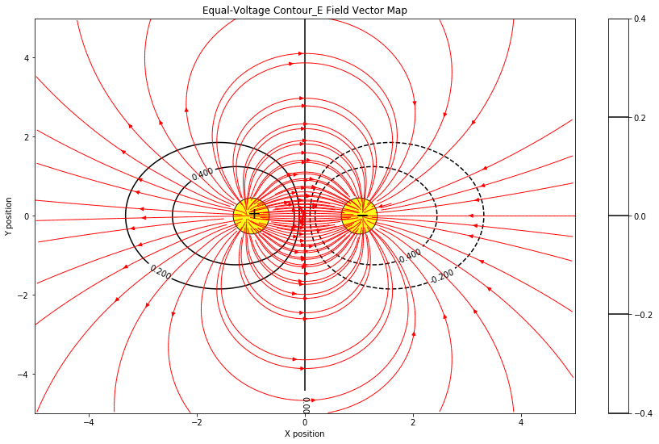

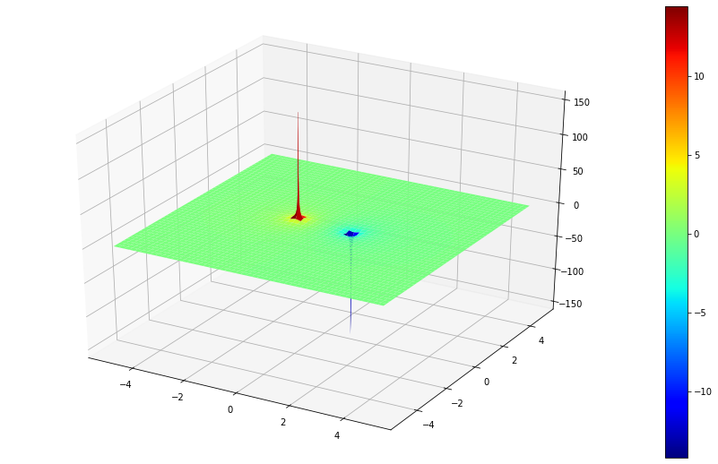

```python
# 實驗: 等位線與電場
# coding=UTF-8
%matplotlib inline

import numpy as np
import scipy as sp
import matplotlib.pyplot as plt
#import matplotlib.mlab as mlab
#from matplotlib.mlab import griddata
#import scipy.interpolate as spinter
#import numpy.random as npr
from mpl_toolkits.mplot3d import Axes3D
#from matplotlib.patches import Circle

N = 1000 #even number
NP = 15 #E field vector
R = 1.0 #position length
QAX = -R
QAY = 0.0
QBX = R
QBY = 0.0

RA = 0.3

FR = 5.0 #field range factor
ec = 1.6e-19  # electron charge
K = 8.988e9 #Coulomb const.
QA = 1.0
QB = -1.0



def getdis_A(x,y):
    da = (x-QAX)**2 + (y-QAY)**2
    da = np.sqrt(da)
    return da

def getdis_B(x,y):
    db = (x-QBX)**2 + (y-QBY)**2
    db = np.sqrt(db)
    return db

def getEX(x, y):
    da = (x-QAX)**2 + (y-QAY)**2
    da = np.sqrt(da)

    db = (x-QBX)**2 + (y-QBY)**2
    db = np.sqrt(db)


    EA = [(x-QAX), (y-QAY)]
    EA = EA*QA/(da**3)

    EB = [(x-QBX), (y-QBY)]
    EB = EB*QB/(db**3)

    Et = EA + EB
    return Et


xr = FR*R
yr = FR*R
x = np.linspace (-xr, xr , N)
y = np.linspace (-yr, yr , N)
xc, yc = np.meshgrid(x,y)

Voltage = (QA/getdis_A(xc, yc)) + (QB/getdis_B(xc, yc))


xp = np.linspace (-xr, xr , NP)
yp = np.linspace (-yr, yr , NP)
xe, ye = np.meshgrid(xp,yp)
EX = (QA/(getdis_A(xe, ye)**3))*(xe-QAX) + (QB/(getdis_B(xe, ye)**3))*(xe-QBX)
EY = (QA/(getdis_A(xe, ye)**3))*(ye-QAY) + (QB/(getdis_B(xe, ye)**3))*(ye-QBY)
Enorm = np.sqrt(EX*EX + EY*EY)
EX = EX/Enorm
EY = EY/Enorm


QX = [QAX,QBX]
QY = [QAY,QBY]
QR = 2000.0

fig, ax = plt.subplots(1, 1, figsize=(15,9))

# fig = plt.figure(figsize=(10,2))
ax.scatter(QX, QY, s=QR, color='yellow', alpha=0.9, edgecolors='k')

ax.text(QAX-0.07, QAY-0.07, r'$+$', fontsize=20)
ax.text(QBX-0.07, QBY-0.07, r'$-$', fontsize=20)




CS = plt.contour(xc, yc, Voltage, np.linspace(-0.4,0.4,5), colors='k')
#CS = plt.contour(xc, yc, Voltage, np.linspace(-0.5,0.5,5), cmap=plt.cm.hot)
#CS = plt.contourf(xc, yc, Voltage, np.linspace(-0.5,0.5,5), cmap=plt.cm.gnuplot)
plt.clabel(CS)  # contour number
plt.colorbar(CS, orientation='vertical')

#plt.pcolormesh(xc, yc, Voltage, cmap=plt.cm.jet) # 3D projection to 2D


#q = plt.quiver(xe,ye,EX,EY,angles='xy',scale=1000,color='r')
#q = plt.quiver(xe,ye,EX,EY,angles='xy',scale_units='xy',scale=5,color='r',headwidth=3, headlength=5)
#strm = plt.streamplot(xe,ye,EX,EY,color='k', linewidth=1, cmap=plt.cm.Greys)

#strm = plt.streamplot(xe,ye,EX,EY,color='r', linewidth=1, density=0.5)
#stream_points =  np.array([x, y])
t = np.linspace(0, 2*np.pi, 100)

stream_xn = 0.1 * FR * R * np.cos(t) - R
stream_y = 0.1 * FR * R * np.sin(t)

stream_xp = 0.1 * FR * R * np.cos(t) + R

stream_pn = list(zip(stream_xn, stream_y))
stream_pp = list(zip(stream_xp, stream_y))

#print(stream_pn)
#stream_points = np.array( list(zip(x,y)  ) )
stream_points_1 = stream_pn
stream_points_2 = stream_pp
#stream_points = np.array([[1,1],[0,0],[2,2]])

#strm = plt.streamplot(xe,ye,EX,EY,color='r',start_points=stream_points, linewidth=1, density=10)
strm_1 = plt.streamplot(xe,ye,EX,EY,color='r',start_points=stream_points_1, linewidth=1, density=5)
strm_2 = plt.streamplot(xe,ye,EX,EY,color='r',start_points=stream_points_2, linewidth=1, density=5)

plt.title('Equal-Voltage Contour_E Field Vector Map')
plt.xlabel('X position')
plt.ylabel('Y position')
#plt.savefig('equalvoltage_contours.png')
#plt.show()


#print zc
fig2 = plt.figure(figsize=(12,7))
ax2 = Axes3D(fig2)
#ax2 = fig.gca(projection='3d')
surf = ax2.plot_surface(xc, yc, Voltage, cmap=plt.cm.jet)
plt.colorbar(surf, orientation='vertical')
#plt.show()
```

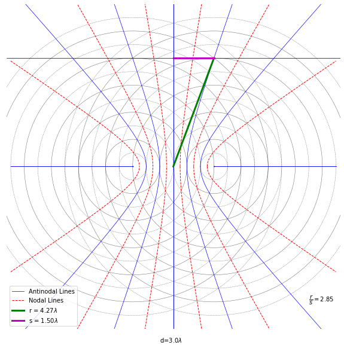

```python
%matplotlib inline

import numpy as np
import scipy as sp
import matplotlib.pyplot as plt

i = np.arange(361)
theta = i*np.pi/180

D = 3
cv = D/2

yd = 4

c1x = -cv
c2x =  cv

N = 6

plt.figure(figsize=(10,10))
for r in range(N):

    x = r*np.cos(theta)+c1x
    xdash = (r+0.5)*np.cos(theta)+c1x
    y = r*np.sin(theta)
    ydash = (r+0.5)*np.sin(theta)

    #t = np.linspace(0, 2*np.pi, 100)
    #x, y = np.cos(t), np.sin(t)

    x2 = r*np.cos(theta)+c2x
    x2dash = (r+0.5)*np.cos(theta)+c2x

    plt.plot(x,y, lw=0.5, c='k', alpha=0.6)
    plt.plot(xdash,ydash,'--', lw=0.5, c='k', alpha=0.5)
    plt.plot(x2,y, lw=0.5 , c='k', alpha=0.6)
    plt.plot(x2dash,ydash,'--',lw=0.5, c='k', alpha=0.5)

plt.scatter(c1x, 0, s=0.8, c='k')
plt.scatter(c2x, 0, s=0.8, c='k')


ax = plt.gca()  # get current axis
ax.spines['right'].set_color('none')  # 將右軸的顏色設為無色
ax.spines['top'].set_visible(False)   # 將上軸設為不可見
ax.spines['left'].set_color('none')  # 將右軸的顏色設為無色
ax.spines['bottom'].set_color('none')  # 將右軸的顏色設為無色
#ax.spines['left'].set_position(('data',0))  #將左軸位置依照資料數值放在 x=0位置
#ax.spines['bottom'].set_position(('data',0)) #將軸位置依照資料數值放在 y=0位置


#plt.xticks([c1x, 0, c2x])
plt.xticks([])
plt.yticks([])
#ax.set_xticklabels([])
#ax.set_yticklabels([])
#plt.grid(True)

plt.axhline(yd, lw=0.7, color='k')  #draw a horizontal line at y=0
#plt.axvline(0, ls='-.', lw=0.5, color='k')
plt.axvline(0, ls='-', lw=1, color='b')


# ===========draw hyperbolic curve================#

wavelength = 1
RANGE = 6
dR = 0.01
edR = 0.001

# antinodal lines
for ja in np.arange (1, D+edR, 1):
    #print(ja)
    ha = ja/2
    hb = np.sqrt(cv**2 - ha**2)

    xn = np.arange(-RANGE, -ha+edR, dR)
    xp = np.arange(ha, RANGE+edR, dR)

    yn = hb*np.sqrt(((xn/ha)**2-1))
    ynn = - yn

    yp = hb*np.sqrt(((xp/ha)**2-1))
    ypp = - yp

    a1, = plt.plot(xn, yn, '-',lw=0.7, color='b')
    plt.plot(xn, ynn,'-', lw=0.7, color='b')
    plt.plot(xp, yp, '-',lw=0.7, color='b')
    plt.plot(xp, ypp, '-',lw=0.7, color='b')

# nodal lines
for jn in np.arange (0.5, D+0.1, 1):
    #print(jn)
    ha = jn/2
    hb = np.sqrt(cv**2 - ha**2)

    xn = np.arange(-RANGE, -ha+edR, dR)
    xp = np.arange(ha, RANGE+edR, dR)

    yn = hb*np.sqrt(((xn/ha)**2-1))
    ynn = - yn

    yp = hb*np.sqrt(((xp/ha)**2-1))
    ypp = - yp

    n1, = plt.plot(xn, yn, '--',lw=1, color='r')
    plt.plot(xn, ynn,'--', lw=1, color='r')
    plt.plot(xp, yp, '--',lw=1, color='r')
    plt.plot(xp, ypp, '--',lw=1, color='r')




# 1st antinode at y = 4
sd = np.sqrt((yd*yd+cv*cv-0.25)/(4*cv*cv-1))
rd = np.sqrt(sd*sd+yd*yd)


rp, = plt.plot([0,sd],[0,yd],'-', lw=3, color='g')
sp, = plt.plot([0,sd],[yd,yd],'-', lw=3, color='m')

plt.axis('equal') # 各軸等長
plt.ylim(bottom = -6, top=6)
plt.xlim(left = -5, right=5)

plt.legend([a1,n1,rp,sp],['Antinodal Lines','Nodal Lines',r'r = $%.2f \lambda$' % rd,r's = $%.2f \lambda$' % sd], loc='lower left')
#plt.title(r'd=$%.1f \lambda$'  %(2*cv))
plt.text(-0.5, -6.5, r'd=$%.1f \lambda$'  %(2*cv))
plt.text(5, -5, r'$\dfrac{r}{s}=%.2f $'  %(rd/sd))


#plt.savefig('3_hyperbolic.jpg', format='jpg', dpi=300)

#plt.show()
```